Reproducible Research : Peer Assessment 1 Author: Chunhui Chen =========================================

## Loading and preprocessing the data

```r
library(lubridate)
setwd("~/Documents/R")
url<-"https://d396qusza40orc.cloudfront.net/repdata%2Fdata%2Factivity.zip"
download.file(url,destfile = "data.zip")
unzip("data.zip")
data<-read.csv("activity.csv")
data$date<-ymd(data$date)
str(data)
```

```
## 'data.frame':    17568 obs. of  3 variables:
##  $ steps   : int  NA NA NA NA NA NA NA NA NA NA ...
##  $ date    : POSIXct, format: "2012-10-01" "2012-10-01" ...
##  $ interval: int  0 5 10 15 20 25 30 35 40 45 ...
```

## What is mean total number of steps taken per day?

### 1. Calculate the total number of steps taken per day

```r
library(dplyr)
dailySteps<-data %>% group_by(date) %>% summarise(TotalSteps=sum(steps,na.rm=TRUE))
head(dailySteps)
```

```
## Source: local data frame [6 x 2]
##
##         date TotalSteps
##       (time)      (int)
## 1 2012-10-01          0
## 2 2012-10-02        126
## 3 2012-10-03      11352
## 4 2012-10-04      12116
## 5 2012-10-05      13294
## 6 2012-10-06      15420
```

### 2. Make a histogram of the total number of steps taken each day

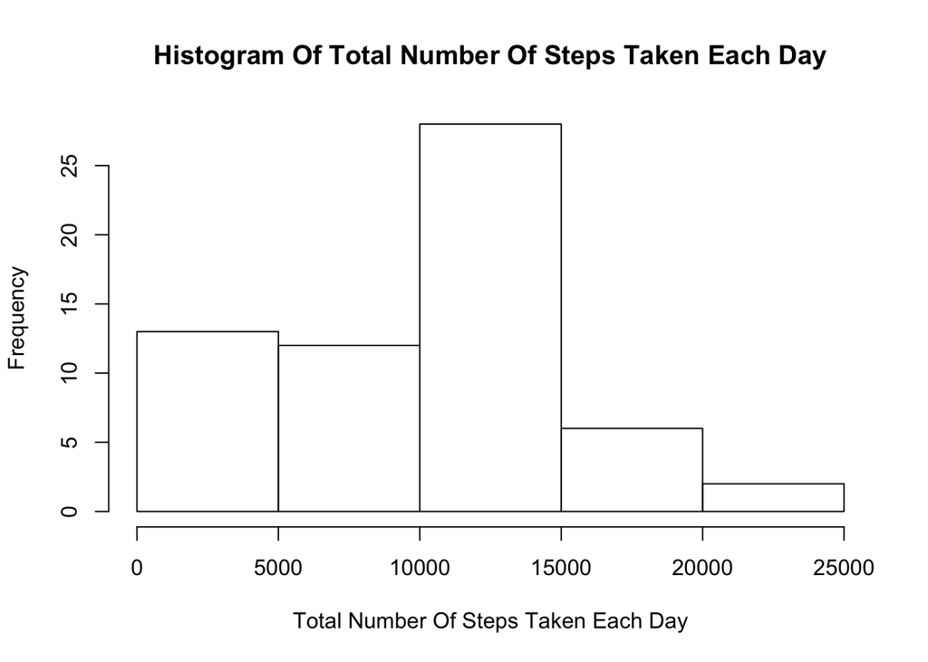

```r
with(dailySteps,hist(TotalSteps,
main="Histogram Of Total Number Of Steps Taken Each Day",
xlab="Total Number Of Steps Taken Each Day"))
```

### 3. Calculate and report the mean and median of the total number of steps taken per day

```r
meanSteps<-round(mean(dailySteps$TotalSteps,na.rm=TRUE),0)
medianSteps<-median(dailySteps$TotalSteps,na.rm=TRUE)
head(dailySteps$TotalSteps)
```

```
## [1]     0   126 11352 12116 13294 15420
```

The mean and median of the total number of steps taken each day is 9354 and 10395 respectively.

## What is the average daily activity pattern?

### 1. Make a time series plot (i.e. 𝚝𝚢𝚙𝚎 = “𝚕”) of the 5-minute interval (x-axis) and the average number of steps taken, averaged across all days (y-axis)

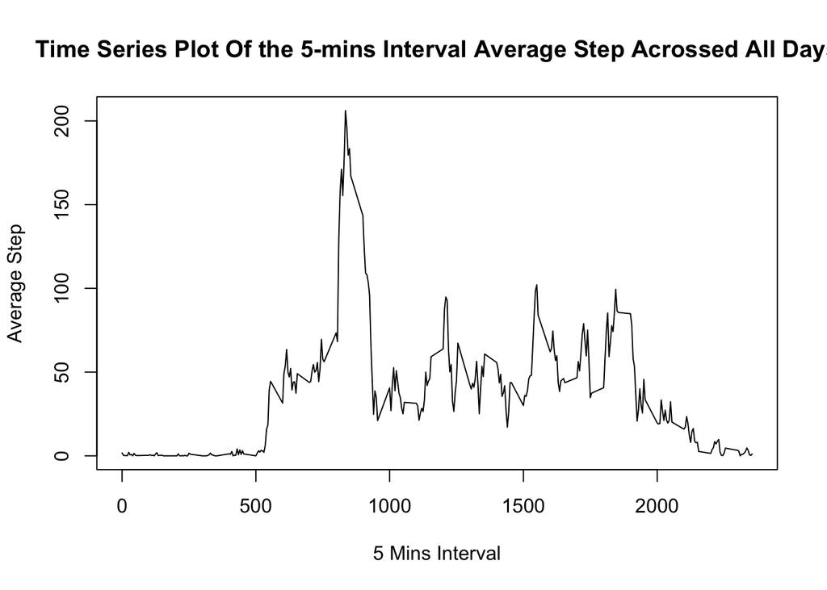

```r
tData<-data %>% group_by(interval) %>% summarise(avgStep=mean(steps,na.rm=TRUE))
with(tData, plot(x=interval,y=avgStep,
main="Time Series Plot Of the 5-mins Interval Average Step Acrossed All Days",ylab="Average Step",xlab="5 Mins Interval",type="l"))
```

```r
maxiStepInterval<-tData[tData$avgStep==max(tData$avgStep),1]
```

## Imputing missing values

### 1. Calculate and report the total number of missing values in the dataset (i.e. the total number of rows with 𝙽𝙰s)

```r
totalMissingVal<-sum(is.na(data))
```

The total number of missing values in the dataset is 2304

### 2. Devise a strategy for filling in all of the missing values in the dataset

```r
library(mice)
md.pattern(data)
```

```
##       date interval steps
## 15264    1        1     1    0
##  2304    1        1     0    1
##          0        0  2304 2304
```

```r
library(VIM)
```

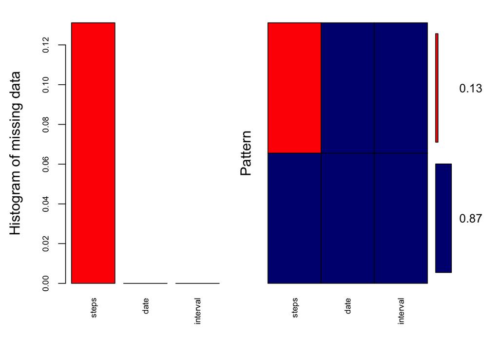

```
##
##  Variables sorted by number of missings:
##  Variable     Count
##     steps 0.1311475
##      date 0.0000000
##  interval 0.0000000
```

```r
aggr_plot <- aggr(data, col=c('navyblue','red'), numbers=TRUE, sortVars=TRUE, labels=names(data), cex.axis=.7, gap=3, ylab=c("Histogram of missing data","Pattern"))
```

The missing values are all in column steps and only 13% of the dataset. We are going to repalce the missing values with the average of the 5 minute interval of the dataset

### 3. Create a new dataset that is equal to the original dataset but with the missing data filled in

```r
NaData<-data %>% subset(is.na(steps)) %>% merge(tData,by="interval") %>% mutate(steps=avgStep) %>% select(steps,date,interval) %>% arrange(date,interval)
imputedData<-na.omit(rbind(NaData,data))
head(imputedData)
```

```
##       steps       date interval
## 1 1.7169811 2012-10-01        0
## 2 0.3396226 2012-10-01        5
## 3 0.1320755 2012-10-01       10
## 4 0.1509434 2012-10-01       15
## 5 0.0754717 2012-10-01       20
## 6 2.0943396 2012-10-01       25
```

### 4. After imputing the missing data, make a histogram of the total number of steps taken each day and Calculate and report the mean and median total number of steps taken per day

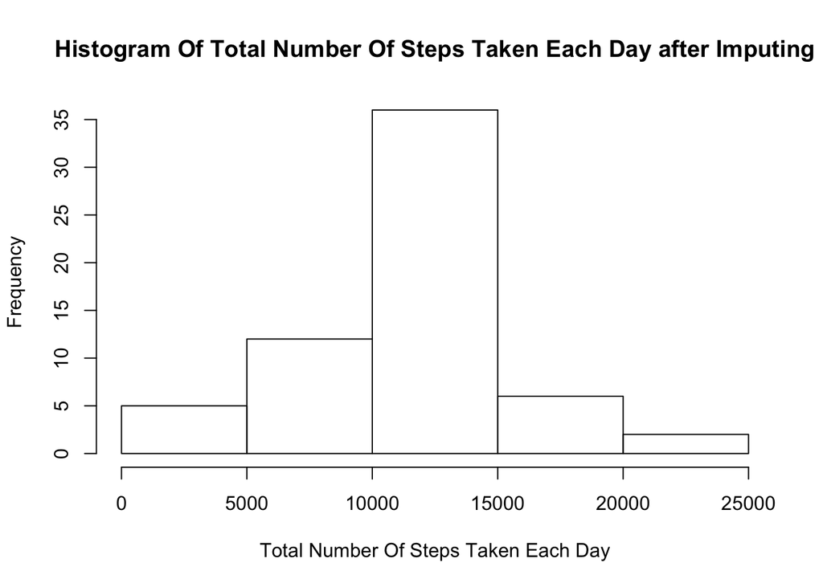

```r
imputedDailySteps<-imputedData %>% group_by(date) %>% summarise(imputedTotalSteps=sum(steps,na.rm=TRUE))
with(imputedDailySteps,hist(imputedTotalSteps,
main="Histogram Of Total Number Of Steps Taken Each Day after Imputing",
xlab="Total Number Of Steps Taken Each Day"))
```

```r
imputedMeanSteps<-round(mean(imputedDailySteps$imputedTotalSteps),0)
imputedMedianSteps<-median(imputedDailySteps$imputedTotalSteps)
summary(imputedDailySteps$imputedTotalSteps)
```

```
##    Min. 1st Qu.  Median    Mean 3rd Qu.    Max.
##      41    9819   10770   10770   12810   21190
```

## Are there differences in activity patterns between weekdays and weekends?

### 1.Create a new factor variable in the dataset with two levels – “weekday” and “weekend” indicating whether a given date is a weekday or weekend day.

```r
wData<-imputedData %>% mutate(day_type=ifelse((weekdays(date)=="Sunday" | weekdays(date)=="Saturday"),"weekend","weekday"))
wIntervalData<-wData %>% group_by(day_type,interval) %>% summarise(avgStep=mean(steps)) %>% arrange(day_type,interval)
```

### 2. Make a panel plot containing a time series plot (i.e. 𝚝𝚢𝚙𝚎 = “𝚕”) of the 5-minute interval (x-axis) and the average number of steps taken, averaged across all weekday days or weekend days (y-axis).

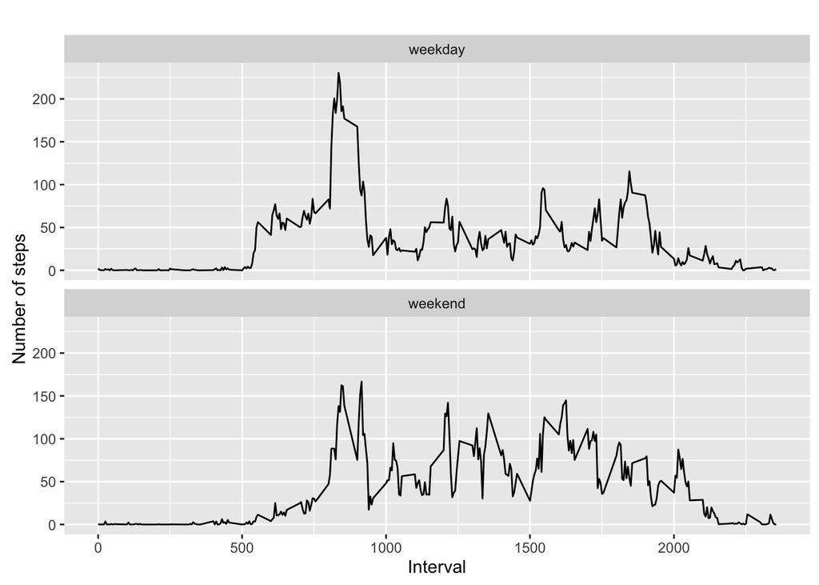

```r
library(ggplot2)
qplot(interval,avgStep,data = wIntervalData, geom=c("line"),xlab = "Interval",ylab = "Number of steps", main = "") +
facet_wrap(~ day_type, ncol = 1)
```